# Illustration of Matthew’s “proxy SNP” idea on GTEx data set

Peter Carbonetto

October 19, 2017

## Outline

This is another vignette exploring a simple fine-mapping idea. In this case, the effect size is very large, sufficient to isolate the association signal to a single SNP.

## Set up environment

Load a few packages.

```r
library(ggplot2)
library(cowplot)
library(varbvs)
```

Also, install the varbvs package from the “finemap” branch on Github.

```r
library(devtools)
install_github("pcarbo/varbvs",ref = "finemap",subdir = "varbvs-R")
```

## Script parameters

The causal variant should be within the credible set with this probability.

```r
credint.prob <- 0.95
```

For identifying the credible set, compute proxy probabilities for all SNPs in LD with the target SNP based on this threshold.

```r
ld.threshold <- 0.2
```

## Load genotype data

Load the GTEx genotype data for the 4,546 SNPs in the *ACTN3* locus.

```r
load("../datafiles/Muscle_Skeletal.ACTN3.1Mb.RData")
storage.mode(X) <- "double"
n <- nrow(X)
p <- ncol(X)
```

## Fit variational approximation to posterior

Fit the fully-factorized variational approximation to the posterior distribution of the coefficients for a linear regression model of a continuous outcome (quantitiative trait), with spike and slab priors on the coefficients.

```r
set.seed(1)
fit <- varbvs(X,Z,y,verbose = FALSE)
```

## Compute proxy probabilities

Compute the correlations between all available SNPs.

```r
R <- cor(X)
```

To test the idea of computing credible SNP sets based on “proxy probabilities”, here I choose the top SNP by posterior inclusion probability (PIP), take all candidate SNPs in LD with this top SNP (based on a pre-specified threshold), then compute the Bayes factors measuring the improvement in “fit” by using the candidate SNPs instead of the top SNP.

```r
top.markers <- summary(fit)$top.vars$index
i    <- top.markers[1]
vars <- which(R[,i]^2 >= ld.threshold)
out  <- varbvsproxybf(X,Z,y,fit,i,vars)
```

Note that the Bayes factors are computed separately for each hyperparameter setting. Here, to simplify the example, we will just use the Bayes factors from the first hyperparameter setting (corresponding to the smallest prior inclusion probability).

This function computes the “proxy probabilities” assuming that exactly 1 SNP is causal, then selects the smallest set of SNPs such that the sum of the proxy probabilities is greater than “pr”.

```r
get.credible.set <- function (bf, pr) {
  pp      <- bf/sum(bf)
  markers <- order(bf,decreasing = TRUE)
  n       <- min(which(cumsum(pp[markers]) > credint.prob))
  return(markers[1:n])
}
```

Get the credible SNP set for the top SNP (for simplicity, using the first hyperparameter setting only).

```r
cr <- vars[get.credible.set(out$BF[,1],credint.prob)]
```

## Plot fine-mapping results

Plot the PIPs of the SNPs, marking the credible SNP set with green circles, and colouring the points according to LD with the top SNP.

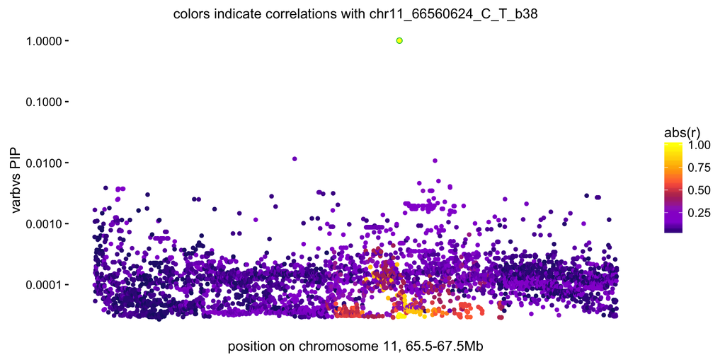

```r
create.finemap.plot <- function (pip, r, markers, plot.title = NULL) {
  clrs <- c("midnightblue","darkviolet","darkorchid","maroon",
            "tomato","orange","gold","yellow")
  dat <- data.frame(pos = 1:p,pip = fit$pip,r = r)
  return(ggplot(mapping = aes(x = pos,y = pip,color = r),
                environment = environment()) +
    geom_point(data = dat,size = 1.75,shape = 20) +
    geom_point(data = dat[markers,],color = "limegreen",shape = 1,size = 1.75) +
    scale_x_continuous(breaks = NULL) +
    scale_y_continuous(trans = "log10",breaks = 10^(-4:0)) +
    scale_color_gradientn(colors = clrs,name = "abs(r)") +
    labs(x = "position on chromosome 11, 65.5-67.5Mb",y = "varbvs PIP",
         title = plot.title) +
    theme_cowplot(font_size = 11) +
    theme(axis.line  = element_blank(),
          plot.title = element_text(size = 11,face = "plain")))
}
print(create.finemap.plot(fit$pip,abs(R[,i]),cr,
      paste("colors indicate correlations with",colnames(X)[i])))
```

We see here that the credible SNP set contains only one SNP, at position 66,560,624 bp on chromosome 11. To understand why, observe that the Bayes factor for this SNP is over 50 times greater than the second-largest Bayes factor.

```r
head(sort(out$BF[,1],decreasing = TRUE),n = 2)
# chr11_66560624_C_T_b38 chr11_66561248_T_C_b38
#             3.891e+261             7.089e+259
```

## Session information

This is the computing environment, version of R and packages that were used to generate these results.

```r
sessionInfo()
# R version 3.4.1 (2017-06-30)
# Platform: x86_64-apple-darwin15.6.0 (64-bit)
# Running under: macOS Sierra 10.12.6
#
# Matrix products: default
# BLAS: /Library/Frameworks/R.framework/Versions/3.4/Resources/lib/libRblas.0.dylib
# LAPACK: /Library/Frameworks/R.framework/Versions/3.4/Resources/lib/libRlapack.dylib
#
# locale:
# [1] en_US.UTF-8/en_US.UTF-8/en_US.UTF-8/C/en_US.UTF-8/en_US.UTF-8
#
# attached base packages:
# [1] stats     graphics  grDevices utils     datasets  methods   base
#
# other attached packages:
# [1] rmarkdown_1.6 varbvs_2.4-9  cowplot_0.8.0 ggplot2_2.2.1
#
# loaded via a namespace (and not attached):
#  [1] Rcpp_0.12.12        knitr_1.17          magrittr_1.5
#  [4] munsell_0.4.3       colorspace_1.3-2    lattice_0.20-35
#  [7] rlang_0.1.1         stringr_1.2.0       plyr_1.8.4
# [10] tools_3.4.1         grid_3.4.1          gtable_0.2.0
# [13] latticeExtra_0.6-28 htmltools_0.3.6     yaml_2.1.14
# [16] lazyeval_0.2.0      digest_0.6.12       rprojroot_1.2
# [19] tibble_1.3.3        Matrix_1.2-10       RColorBrewer_1.1-2
# [22] evaluate_0.10.1     labeling_0.3        stringi_1.1.5
# [25] compiler_3.4.1      scales_0.4.1.9002   backports_1.1.0
```